# FVRR Stock Price Analysis

```python
#input the necessary libraries
```

```python
import pandas as pd
import numpy as np
import matplotlib.pyplot as plt
import seaborn as sns
import os
```

```python
##Loading the Excel files
data= pd.read_csv("FVRR.csv",index_col='Date',parse_dates=True)
```

```python
data.head()
```

| Date | Open | High | Low | Close | Adj Close | Volume |
| --- | --- | --- | --- | --- | --- | --- |
| 2019-06-10 | 26.000000 | 44.250000 | 25.549999 | 31.490000 | 31.490000 | 32321800 |
| 2019-06-17 | 32.810001 | 35.919998 | 27.573999 | 27.750000 | 27.750000 | 11348400 |
| 2019-06-24 | 28.000000 | 30.950001 | 27.070000 | 29.700001 | 29.700001 | 3445900 |
| 2019-07-01 | 29.790001 | 30.330000 | 26.799999 | 27.250000 | 27.250000 | 1529900 |
| 2019-07-08 | 27.139999 | 27.299999 | 22.139999 | 23.480000 | 23.480000 | 2549200 |

```python
data.shape
```

```
(184, 6)
```

```python
data.info()
```

```
<class 'pandas.core.frame.DataFrame'>
DatetimeIndex: 184 entries, 2019-06-10 to 2022-12-12
Data columns (total 6 columns):
 #   Column     Non-Null Count  Dtype
---  ------     --------------  -----
 0   Open       184 non-null    float64
 1   High       184 non-null    float64
 2   Low        184 non-null    float64
 3   Close      184 non-null    float64
 4   Adj Close  184 non-null    float64
 5   Volume     184 non-null    int64
dtypes: float64(5), int64(1)
memory usage: 10.1 KB
```

```python
data.isnull().sum()
```

```
Open         0
High         0
Low          0
Close        0
Adj Close    0
Volume       0
dtype: int64
```

```python
data.describe()
```

|  | Open | High | Low | Close | Adj Close | Volume |
| --- | --- | --- | --- | --- | --- | --- |
| count | 184.000000 | 184.000000 | 184.000000 | 184.000000 | 184.000000 | 1.840000e+02 |
| mean | 100.794864 | 108.841832 | 92.322652 | 100.821957 | 100.821957 | 3.967153e+06 |
| std | 80.780343 | 86.134382 | 73.008586 | 80.696196 | 80.696196 | 3.323793e+06 |
| min | 18.110001 | 18.559999 | 17.110001 | 18.250000 | 18.250000 | 3.681000e+05 |
| 25% | 30.442501 | 33.412501 | 27.447999 | 30.737500 | 30.737500 | 2.204900e+06 |
| 50% | 68.915001 | 74.569999 | 63.024999 | 68.799999 | 68.799999 | 3.408150e+06 |
| 75% | 177.037498 | 187.293747 | 164.437504 | 177.774997 | 177.774997 | 4.874650e+06 |
| max | 332.290009 | 336.000000 | 286.029999 | 323.100006 | 323.100006 | 3.232180e+07 |

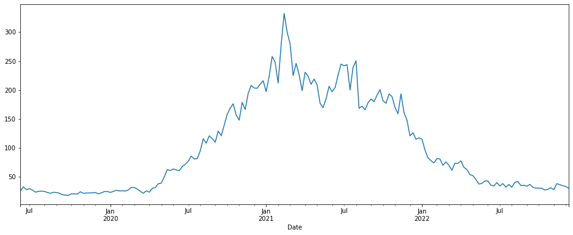

```python
data['Open'].plot(figsize=(16,6))
```

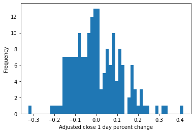

```python
data['Close'].pct_change().plot.hist(bins=50)
plt.xlabel("Adjusted close 1 day percent change")
plt.show()
```

```python
import datetime as dt
import pandas as pd
import numpy as np
from numpy import arange
import matplotlib.pyplot as plt
from pandas import read_csv
from sklearn import metrics
from sklearn.model_selection import train_test_split
from sklearn.ensemble import RandomForestRegressor
from sklearn.preprocessing import StandardScaler
from sklearn.model_selection import RandomizedSearchCV
```

```python
data.head()
```

| Date | Open | High | Low | Close | Adj Close | Volume |
| --- | --- | --- | --- | --- | --- | --- |
| 2019-06-10 | 26.000000 | 44.250000 | 25.549999 | 31.490000 | 31.490000 | 32321800 |
| 2019-06-17 | 32.810001 | 35.919998 | 27.573999 | 27.750000 | 27.750000 | 11348400 |
| 2019-06-24 | 28.000000 | 30.950001 | 27.070000 | 29.700001 | 29.700001 | 3445900 |
| 2019-07-01 | 29.790001 | 30.330000 | 26.799999 | 27.250000 | 27.250000 | 1529900 |
| 2019-07-08 | 27.139999 | 27.299999 | 22.139999 | 23.480000 | 23.480000 | 2549200 |

```python
x = data.iloc[:, 0:5].values
y = data.iloc[:, 4].values
```

# x is holding values for the open, high, low, close and adj close columns. yis holding values for the adj-close column. The other columns, including that of volume, were not selected for the process because they will not be needed. Five features were used.

```python
x_train, x_test, y_train, y_test = train_test_split(x, y, test_size=0.26,  random_state=0)
```

Step 4: Scaling the features

```python
scale = StandardScaler()
x_train = scale.fit_transform(x_train)
x_test = scale.transform(x_test)
```

Step 4: Hyperparemater tuning

For a random forest regression model, the best parameters to consider are:

```
n_estimators — number of trees in the forest
max_depth — maximum depth in a tree
min_samples_split — minimum number of data points before the sample is split
min_samples_leaf — minimum number of leaf nodes that are required to be sampled
bootstrap — sampling for data points, true or false
random_state — generated random numbers for the random forest.
```

```python
model = RandomForestRegressor(n_estimators=500, random_state=42, min_samples_split=2, min_samples_leaf=1, max_depth=10, bootstrap=True)
model.fit(x_train, y_train)
predict = model.predict(x_test)
print(predict)
print(predict.shape)
```

```
[ 82.37778098 242.17698346  25.28316044 246.66452343 109.11465905
 217.86769912 113.32679831  37.37243998  25.84564002  33.02665947
  31.54887993 161.57786328  24.87330003 172.05242292  51.85664065
  75.86435941  20.66971984 124.78381909  55.90644055 167.48964129
  36.71405963  39.22592081  81.48178077  26.42891994  38.61069964
  23.5522      72.73379807 118.79939854 200.26435924 188.86320102
 171.46788264 115.65575736 244.68430288  23.19687934  31.25851988
 104.74079918 226.91216056  22.28858881  37.14814068 249.10438294
  31.26011983 182.63446228  74.03177832  23.04098033  24.84764009
 209.10083552 126.42869941 250.88060269]
(48,)
```

```python
grid_rf = {
'n_estimators': [20, 50, 100, 500, 1000],
'max_depth': np.arange(1, 15, 1),
'min_samples_split': [2, 10, 9],
'min_samples_leaf': np.arange(1, 15, 2, dtype=int),
'bootstrap': [True, False],
'random_state': [1, 2, 30, 42]
}
rscv = RandomizedSearchCV(estimator=model, param_distributions=grid_rf, cv=3, n_jobs=-1, verbose=2, n_iter=200)
rscv_fit = rscv.fit(x_train, y_train)
best_parameters = rscv_fit.best_params_
print(best_parameters)
```

```
Fitting 3 folds for each of 200 candidates, totalling 600 fits
{'random_state': 2, 'n_estimators': 500, 'min_samples_split': 2, 'min_samples_leaf': 1, 'max_depth': 13, 'bootstrap': False}
```

Statistical metrics and performance evaluation

Root mean square error (RMSE)

```python
print("Mean Absolute Error:", round(metrics.mean_absolute_error(y_test, predict), 4))
print("Mean Squared Error:", round(metrics.mean_squared_error(y_test, predict), 4))
print("Root Mean Squared Error:", round(np.sqrt(metrics.mean_squared_error(y_test, predict)), 4))
print("(R^2) Score:", round(metrics.r2_score(y_test, predict), 4))
print(f'Train Score : {model.score(x_train, y_train) * 100:.2f}% and Test Score : {model.score(x_test, y_test) * 100:.2f}% using Random Tree Regressor.')
errors = abs(predict - y_test)
mape = 100 * (errors / y_test)
accuracy = 100 - np.mean(mape)
print('Accuracy:', round(accuracy, 2), '%.')
```

```
Mean Absolute Error: 2.2661
Mean Squared Error: 23.7175
Root Mean Squared Error: 4.8701
(R^2) Score: 0.9963
Train Score : 99.95% and Test Score : 99.63% using Random Tree Regressor.
Accuracy: 98.13 %.
```

```python
predictions = pd.DataFrame({"Predictions": predict},
index=pd.date_range(start=data.index[-1], periods=len(predict), freq="D"))
predictions.to_csv("Predicted-price-data.csv")
#colllects future days from predicted values
oneyear_df = pd.DataFrame(predictions[:252])
oneyear_df.to_csv("one-year-predictions.csv")
onemonth_df = pd.DataFrame(predictions[:21])
onemonth_df.to_csv("one-month-predictions.csv")
fivedays_df = pd.DataFrame(predictions[:5])
fivedays_df.to_csv("five-days-predictions.csv")
```

```python
predictions
```

|  | Predictions |
| --- | --- |
| 2022-12-12 | 82.377781 |
| 2022-12-13 | 242.176983 |
| 2022-12-14 | 25.283160 |
| 2022-12-15 | 246.664523 |
| 2022-12-16 | 109.114659 |
| 2022-12-17 | 217.867699 |
| 2022-12-18 | 113.326798 |
| 2022-12-19 | 37.372440 |
| 2022-12-20 | 25.845640 |
| 2022-12-21 | 33.026659 |
| 2022-12-22 | 31.548880 |
| 2022-12-23 | 161.577863 |
| 2022-12-24 | 24.873300 |
| 2022-12-25 | 172.052423 |
| 2022-12-26 | 51.856641 |
| 2022-12-27 | 75.864359 |
| 2022-12-28 | 20.669720 |
| 2022-12-29 | 124.783819 |
| 2022-12-30 | 55.906441 |
| 2022-12-31 | 167.489641 |
| 2023-01-01 | 36.714060 |
| 2023-01-02 | 39.225921 |
| 2023-01-03 | 81.481781 |
| 2023-01-04 | 26.428920 |
| 2023-01-05 | 38.610700 |
| 2023-01-06 | 23.552200 |
| 2023-01-07 | 72.733798 |
| 2023-01-08 | 118.799399 |
| 2023-01-09 | 200.264359 |
| 2023-01-10 | 188.863201 |
| 2023-01-11 | 171.467883 |
| 2023-01-12 | 115.655757 |
| 2023-01-13 | 244.684303 |
| 2023-01-14 | 23.196879 |
| 2023-01-15 | 31.258520 |
| 2023-01-16 | 104.740799 |
| 2023-01-17 | 226.912161 |
| 2023-01-18 | 22.288589 |
| 2023-01-19 | 37.148141 |
| 2023-01-20 | 249.104383 |
| 2023-01-21 | 31.260120 |
| 2023-01-22 | 182.634462 |
| 2023-01-23 | 74.031778 |
| 2023-01-24 | 23.040980 |
| 2023-01-25 | 24.847640 |
| 2023-01-26 | 209.100836 |
| 2023-01-27 | 126.428699 |
| 2023-01-28 | 250.880603 |

```python
oneyear_df
```

|  | Predictions |
| --- | --- |
| 2022-12-12 | 82.377781 |
| 2022-12-13 | 242.176983 |
| 2022-12-14 | 25.283160 |
| 2022-12-15 | 246.664523 |
| 2022-12-16 | 109.114659 |
| 2022-12-17 | 217.867699 |
| 2022-12-18 | 113.326798 |
| 2022-12-19 | 37.372440 |
| 2022-12-20 | 25.845640 |
| 2022-12-21 | 33.026659 |
| 2022-12-22 | 31.548880 |
| 2022-12-23 | 161.577863 |
| 2022-12-24 | 24.873300 |
| 2022-12-25 | 172.052423 |
| 2022-12-26 | 51.856641 |
| 2022-12-27 | 75.864359 |
| 2022-12-28 | 20.669720 |
| 2022-12-29 | 124.783819 |
| 2022-12-30 | 55.906441 |
| 2022-12-31 | 167.489641 |
| 2023-01-01 | 36.714060 |
| 2023-01-02 | 39.225921 |
| 2023-01-03 | 81.481781 |
| 2023-01-04 | 26.428920 |
| 2023-01-05 | 38.610700 |
| 2023-01-06 | 23.552200 |
| 2023-01-07 | 72.733798 |
| 2023-01-08 | 118.799399 |
| 2023-01-09 | 200.264359 |
| 2023-01-10 | 188.863201 |
| 2023-01-11 | 171.467883 |
| 2023-01-12 | 115.655757 |
| 2023-01-13 | 244.684303 |
| 2023-01-14 | 23.196879 |
| 2023-01-15 | 31.258520 |
| 2023-01-16 | 104.740799 |
| 2023-01-17 | 226.912161 |
| 2023-01-18 | 22.288589 |
| 2023-01-19 | 37.148141 |
| 2023-01-20 | 249.104383 |
| 2023-01-21 | 31.260120 |
| 2023-01-22 | 182.634462 |
| 2023-01-23 | 74.031778 |
| 2023-01-24 | 23.040980 |
| 2023-01-25 | 24.847640 |
| 2023-01-26 | 209.100836 |
| 2023-01-27 | 126.428699 |
| 2023-01-28 | 250.880603 |

```python
onemonth_df
```

|  | Predictions |
| --- | --- |
| 2022-12-12 | 82.377781 |
| 2022-12-13 | 242.176983 |
| 2022-12-14 | 25.283160 |
| 2022-12-15 | 246.664523 |
| 2022-12-16 | 109.114659 |
| 2022-12-17 | 217.867699 |
| 2022-12-18 | 113.326798 |
| 2022-12-19 | 37.372440 |
| 2022-12-20 | 25.845640 |
| 2022-12-21 | 33.026659 |
| 2022-12-22 | 31.548880 |
| 2022-12-23 | 161.577863 |
| 2022-12-24 | 24.873300 |
| 2022-12-25 | 172.052423 |
| 2022-12-26 | 51.856641 |
| 2022-12-27 | 75.864359 |
| 2022-12-28 | 20.669720 |
| 2022-12-29 | 124.783819 |
| 2022-12-30 | 55.906441 |
| 2022-12-31 | 167.489641 |
| 2023-01-01 | 36.714060 |

```python
fivedays_df
```

|  | Predictions |
| --- | --- |
| 2022-12-12 | 82.377781 |
| 2022-12-13 | 242.176983 |
| 2022-12-14 | 25.283160 |
| 2022-12-15 | 246.664523 |
| 2022-12-16 | 109.114659 |

```
Buy price and date
    Unnamed: 0  Predictions
16  2022-12-28     20.66972
Sell price and date
    Unnamed: 0  Predictions
47  2023-01-28   250.880603
```

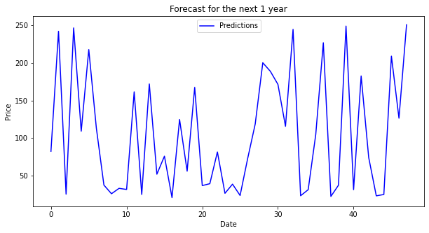

```python
oneyear_df_pred = pd.read_csv("one-year-predictions.csv")
#oneyear_df_pred.set_index("Date", inplace=True)
buy_price = min(oneyear_df_pred["Predictions"])
sell_price = max(oneyear_df_pred["Predictions"])
oneyear_buy = oneyear_df_pred.loc[oneyear_df_pred["Predictions"] == buy_price]
oneyear_sell = oneyear_df_pred.loc[oneyear_df_pred["Predictions"] == sell_price]
print("Buy price and date")
print(oneyear_buy)
print("Sell price and date")
print(oneyear_sell)
oneyear_df_pred["Predictions"].plot(figsize=(10, 5), title="Forecast for the next 1 year", color="blue")
plt.xlabel("Date")
plt.ylabel("Price")
plt.legend()
plt.show()
```

One month prediction:

```
Buy price and date
    Unnamed: 0  Predictions
16  2022-12-28     20.66972
Sell price and date
   Unnamed: 0  Predictions
3  2022-12-15   246.664523
```

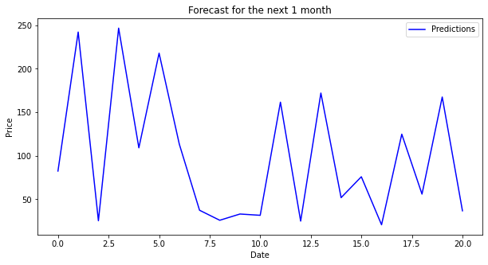

```python
onemonth_df_pred = pd.read_csv("one-month-predictions.csv")
#onemonth_df_pred.set_index("Date", inplace=True)
buy_price = min(onemonth_df_pred["Predictions"])
sell_price = max(onemonth_df_pred["Predictions"])
onemonth_buy = onemonth_df_pred.loc[onemonth_df_pred["Predictions"] == buy_price]
onemonth_sell = onemonth_df_pred.loc[onemonth_df_pred["Predictions"] == sell_price]
print("Buy price and date")
print(onemonth_buy)
print("Sell price and date")
print(onemonth_sell)
onemonth_df_pred["Predictions"].plot(figsize=(10, 5), title="Forecast for the next 1 month", color="blue")
plt.xlabel("Date")
plt.ylabel("Price")
plt.legend()
plt.show()
```

Five days prediction :

```
Buy price and date
   Unnamed: 0  Predictions
2  2022-12-14     25.28316
Sell price and date
   Unnamed: 0  Predictions
3  2022-12-15   246.664523
```

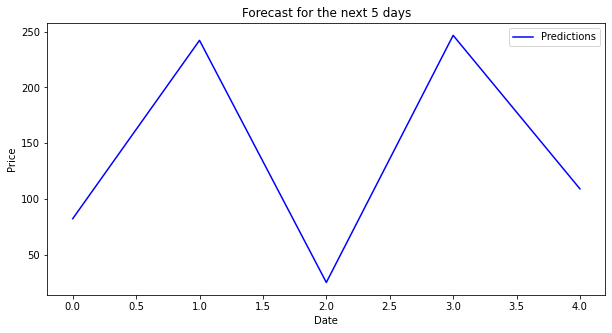

```python
fivedays_df_pred = pd.read_csv("five-days-predictions.csv")
#fivedays_df_pred.set_index("Date", inplace=True)
buy_price = min(fivedays_df_pred["Predictions"])
sell_price = max(fivedays_df_pred["Predictions"])
fivedays_buy = fivedays_df_pred.loc[fivedays_df_pred["Predictions"] == buy_price]
fivedays_sell = fivedays_df_pred.loc[fivedays_df_pred["Predictions"] == sell_price]
print("Buy price and date")
print(fivedays_buy)
print("Sell price and date")
print(fivedays_sell)
fivedays_df_pred["Predictions"].plot(figsize=(10, 5), title="Forecast for the next 5 days", color="blue")
plt.xlabel("Date")
plt.ylabel("Price")
plt.legend()
plt.show()
```

Conclusion

There are different approaches to solving these problems. Their performance can differ from mathematical analysis for prediction to sentiment analysis, financial news articles, and expert reviews.Overall, random forest is mostly fast, simple, and flexible, but not without some limitations.

# STOCK MARKET PREDICTIONS USING LSTM

```python
##Loading the Excel files
df1= pd.read_csv("FVRR.csv",index_col='Date',parse_dates=True)
```

```python
df1.head()
```

| Date | Open | High | Low | Close | Adj Close | Volume |
| --- | --- | --- | --- | --- | --- | --- |
| 2019-06-10 | 26.000000 | 44.250000 | 25.549999 | 31.490000 | 31.490000 | 32321800 |
| 2019-06-17 | 32.810001 | 35.919998 | 27.573999 | 27.750000 | 27.750000 | 11348400 |
| 2019-06-24 | 28.000000 | 30.950001 | 27.070000 | 29.700001 | 29.700001 | 3445900 |
| 2019-07-01 | 29.790001 | 30.330000 | 26.799999 | 27.250000 | 27.250000 | 1529900 |
| 2019-07-08 | 27.139999 | 27.299999 | 22.139999 | 23.480000 | 23.480000 | 2549200 |

```python
df1.shape
```

```
(184, 6)
```

```python
df1=df1['Close']
```

```python
df1
```

```
Date
2019-06-10    31.490000
2019-06-17    27.750000
2019-06-24    29.700001
2019-07-01    27.250000
2019-07-08    23.480000
                ...
2022-11-14    37.150002
2022-11-21    35.090000
2022-11-28    33.860001
2022-12-05    30.950001
2022-12-12    31.129999
Name: Close, Length: 184, dtype: float64
```

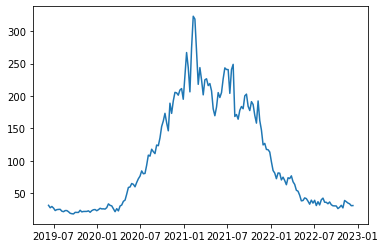

```python
import matplotlib.pyplot as plt
plt.plot(df1)
```

```python
#Importing Keras Libraries and Packages
from keras.models import Sequential
from keras.layers import Dense
from keras.layers import LSTM
from keras.layers import Dropout
```

```python
from sklearn.preprocessing import MinMaxScaler
scaler=MinMaxScaler(feature_range=(0,1))
df1=scaler.fit_transform(np.array(df1).reshape(-1,1))
```

```python
df1
```

```
array([[0.04343119],
       [0.03116287],
       [0.03755946],
       [0.02952272],
       [0.01715598],
       [0.0217484 ],
       [0.0227981 ],
       [0.02325734],
       [0.01381007],
       [0.01125143],
       [0.01686075],
       [0.01686075],
       [0.01108742],
       [0.00334591],
       [0.00101689],
       [0.        ],
       [0.00787272],
       [0.00787272],
       [0.00738068],
       [0.0184681 ],
       [0.01026734],
       [0.01239954],
       [0.01239954],
       [0.01262916],
       [0.01561424],
       [0.00836477],
       [0.01656552],
       [0.02109234],
       [0.02210923],
       [0.01620469],
       [0.02148597],
       [0.02853863],
       [0.02538954],
       [0.02571757],
       [0.02450385],
       [0.03165491],
       [0.05071346],
       [0.04339839],
       [0.04064294],
       [0.02542234],
```

[output cut: 129 more lines]

```
       [0.06042315],
       [0.04644907],
       [0.04106938],
       [0.04047892],
       [0.04015089],
       [0.02693127],
       [0.03359029],
       [0.0434968 ],
       [0.0305068 ],
       [0.06803346],
       [0.06199771],
       [0.05524028],
       [0.05120551],
       [0.04165984],
       [0.04225028]])
```

```python
len(df1)
```

```
184
```

```python
##splitting dataset into train and test split
training_size=int(len(df1)*0.65)
test_size=len(df1)-training_size
train_data,test_data=df1[0:training_size,:],df1[training_size:len(df1),:1]
```

```python
training_size,test_size
```

```
(119, 65)
```

```python
import numpy
# convert an array of values into a dataset matrix
def create_dataset(dataset, time_step=1):
	dataX, dataY = [], []
	for i in range(len(dataset)-time_step-1):
		a = dataset[i:(i+time_step), 0]   ###i=0, 0,1,2,3-----99   100
		dataX.append(a)
		dataY.append(dataset[i + time_step, 0])
	return numpy.array(dataX), numpy.array(dataY)
```

```python
# reshape into X=t,t+1,t+2,t+3 and Y=t+4
time_step = 10
X_train, y_train = create_dataset(train_data, time_step)
X_test, ytest = create_dataset(test_data, time_step)
```

```python
print(X_train.shape), print(y_train.shape)
```

```
(108, 10)
(108,)
```

```
(None, None)
```

```python
print(X_test.shape), print(ytest.shape)
```

```
(54, 10)
(54,)
```

```
(None, None)
```

```python
# reshape input to be [samples, time steps, features] which is required for LSTM
X_train =X_train.reshape(X_train.shape[0],X_train.shape[1] , 1)
X_test = X_test.reshape(X_test.shape[0],X_test.shape[1] , 1)
```

```python
### Create the Stacked LSTM model
from tensorflow.keras.models import Sequential
from tensorflow.keras.layers import Dense
from tensorflow.keras.layers import LSTM
```

```python
model=Sequential()
model.add(LSTM(50,return_sequences=True,input_shape=(10,1)))
model.add(LSTM(50,return_sequences=True))
model.add(LSTM(50))
model.add(Dense(1))
model.compile(loss='mean_squared_error',optimizer='adam')
```

```python
model.summary()
```

```
Model: "sequential_10"
_________________________________________________________________
 Layer (type)                Output Shape              Param #
=================================================================
 lstm_17 (LSTM)              (None, 10, 50)            10400

 lstm_18 (LSTM)              (None, 10, 50)            20200

 lstm_19 (LSTM)              (None, 50)                20200

 dense_19 (Dense)            (None, 1)                 51

=================================================================
Total params: 50,851
Trainable params: 50,851
Non-trainable params: 0
_________________________________________________________________
```

```python
model.fit(X_train,y_train,validation_data=(X_test,ytest),epochs=100)
```

```
<keras.callbacks.History at 0x12e5cb0f460>
```

```python
import tensorflow as tf
```

```python
### Lets Do the prediction and check performance metrics
train_predict=model.predict(X_train)
test_predict=model.predict(X_test)
```

```python
##Transformback to original form
train_predict=scaler.inverse_transform(train_predict)
test_predict=scaler.inverse_transform(test_predict)
```

```python
### Calculate RMSE performance metrics
import math
from sklearn.metrics import mean_squared_error
math.sqrt(mean_squared_error(y_train,train_predict))
```

```
153.0682183330907
```

```python
### Test Data RMSE
math.sqrt(mean_squared_error(ytest,test_predict))
```

```
107.49305774766755
```

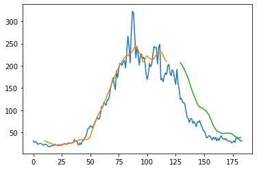

```python
### Plotting
# shift train predictions for plotting
look_back=10
trainPredictPlot = numpy.empty_like(df1)
trainPredictPlot[:, :] = np.nan
trainPredictPlot[look_back:len(train_predict)+look_back, :] = train_predict
# shift test predictions for plotting
testPredictPlot = numpy.empty_like(df1)
testPredictPlot[:, :] = numpy.nan
testPredictPlot[len(train_predict)+(look_back*2)+1:len(df1)-1, :] = test_predict
# plot baseline and predictions
plt.plot(scaler.inverse_transform(df1))
plt.plot(trainPredictPlot)
plt.plot(testPredictPlot)
plt.show()
```

```python
len(test_data)
```

```
65
```

```python
x_input=test_data[55:].reshape(1,-1)
x_input.shape
```

```
(1, 10)
```

```python
temp_input=list(x_input)
temp_input=temp_input[0].tolist()
```

```python
temp_input
```

```
[0.026931273867188313,
 0.03359028964559049,
 0.043496800849661135,
 0.030506802745478706,
 0.068033464299817,
 0.06199770912912497,
 0.05524028101872501,
 0.051205513179488,
 0.04165983516496963,
 0.04225028291454258]
```

```python
# demonstrate prediction for next 10 days
from numpy import array

lst_output=[]
n_steps=10
i=0
while(i<30):

    if(len(temp_input)>10):
        #print(temp_input)
        x_input=np.array(temp_input[1:])
        print("{} day input {}".format(i,x_input))
        x_input=x_input.reshape(1,-1)
        x_input = x_input.reshape((1, n_steps, 1))
        #print(x_input)
        yhat = model.predict(x_input, verbose=0)
        print("{} day output {}".format(i,yhat))
        temp_input.extend(yhat[0].tolist())
        temp_input=temp_input[1:]
        #print(temp_input)
        lst_output.extend(yhat.tolist())
        i=i+1
    else:
        x_input = x_input.reshape((1, n_steps,1))
        yhat = model.predict(x_input, verbose=0)
        print(yhat[0])
        temp_input.extend(yhat[0].tolist())
        print(len(temp_input))
        lst_output.extend(yhat.tolist())
        i=i+1


print(lst_output)
```

```
[0.07448479]
11
1 day input [0.03359029 0.0434968  0.0305068  0.06803346 0.06199771 0.05524028
 0.05120551 0.04165984 0.04225028 0.07448479]
1 day output [[0.08019179]]
2 day input [0.0434968  0.0305068  0.06803346 0.06199771 0.05524028 0.05120551
 0.04165984 0.04225028 0.07448479 0.08019179]
2 day output [[0.08528248]]
3 day input [0.0305068  0.06803346 0.06199771 0.05524028 0.05120551 0.04165984
 0.04225028 0.07448479 0.08019179 0.08528248]
3 day output [[0.08969923]]
4 day input [0.06803346 0.06199771 0.05524028 0.05120551 0.04165984 0.04225028
 0.07448479 0.08019179 0.08528248 0.08969923]
4 day output [[0.09786681]]
5 day input [0.06199771 0.05524028 0.05120551 0.04165984 0.04225028 0.07448479
 0.08019179 0.08528248 0.08969923 0.09786681]
5 day output [[0.10074953]]
6 day input [0.05524028 0.05120551 0.04165984 0.04225028 0.07448479 0.08019179
 0.08528248 0.08969923 0.09786681 0.10074953]
6 day output [[0.10678715]]
7 day input [0.05120551 0.04165984 0.04225028 0.07448479 0.08019179 0.08528248
 0.08969923 0.09786681 0.10074953 0.10678715]
7 day output [[0.11581201]]
8 day input [0.04165984 0.04225028 0.07448479 0.08019179 0.08528248 0.08969923
 0.09786681 0.10074953 0.10678715 0.11581201]
8 day output [[0.12701857]]
9 day input [0.04225028 0.07448479 0.08019179 0.08528248 0.08969923 0.09786681
 0.10074953 0.10678715 0.11581201 0.12701857]
9 day output [[0.14111562]]
10 day input [0.07448479 0.08019179 0.08528248 0.08969923 0.09786681 0.10074953
 0.10678715 0.11581201 0.12701857 0.14111562]
10 day output [[0.15611756]]
11 day input [0.08019179 0.08528248 0.08969923 0.09786681 0.10074953 0.10678715
 0.11581201 0.12701857 0.14111562 0.15611756]
11 day output [[0.16708858]]
12 day input [0.08528248 0.08969923 0.09786681 0.10074953 0.10678715 0.11581201
 0.12701857 0.14111562 0.15611756 0.16708858]
12 day output [[0.17930447]]
13 day input [0.08969923 0.09786681 0.10074953 0.10678715 0.11581201 0.12701857
 0.14111562 0.15611756 0.16708858 0.17930447]
```

[output cut: 35 more lines]

```
 0.35034347 0.37449604 0.39963391 0.42545158]
25 day output [[0.45162475]]
26 day input [0.24311404 0.26286864 0.28363273 0.30522776 0.32743996 0.35034347
 0.37449604 0.39963391 0.42545158 0.45162475]
26 day output [[0.47787002]]
27 day input [0.26286864 0.28363273 0.30522776 0.32743996 0.35034347 0.37449604
 0.39963391 0.42545158 0.45162475 0.47787002]
27 day output [[0.50381434]]
28 day input [0.28363273 0.30522776 0.32743996 0.35034347 0.37449604 0.39963391
 0.42545158 0.45162475 0.47787002 0.50381434]
28 day output [[0.5291289]]
29 day input [0.30522776 0.32743996 0.35034347 0.37449604 0.39963391 0.42545158
 0.45162475 0.47787002 0.50381434 0.52912891]
29 day output [[0.5534905]]
[[0.07448478788137436], [0.08019179105758667], [0.08528248220682144], [0.08969923108816147], [0.09786681085824966], [0.10074952989816666], [0.10678714513778687], [0.11581201106309891], [0.12701857089996338], [0.14111562073230743], [0.15611755847930908], [0.167088583111763], [0.17930446565151215], [0…
```

```python
day_new=np.arange(1,101)
day_pred=np.arange(101,131)
```

```python
len(df1)
```

```
184
```

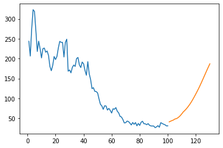

```python
plt.plot(day_new,scaler.inverse_transform(df1[84:]))
plt.plot(day_pred,scaler.inverse_transform(lst_output))
```

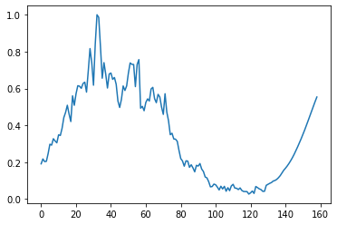

```python
df3=df1.tolist()
df3.extend(lst_output)
plt.plot(df3[55:])
```

```python
df3=scaler.inverse_transform(df3).tolist()
```

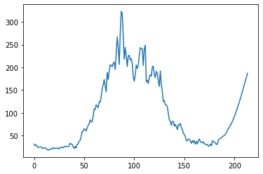

```python
plt.plot(df3)
```

CONCLUSION

The stock price of FVRR is expected to increase in the coming months